# Praktikum 1

G1401231083 - Gafin Khalifa Nalya

2025-08-30

```r
library(readxl)
library(rio)
library("forecast")
```

```r
library("graphics")
library("TTR")
library(ggplot2)
```

### Import Data

```r
sales<- read_excel("sales.xlsx")
sales
```

```
## # A tibble: 730 × 2
##    Date                Total_Sales
##    <dttm>                    <dbl>
##  1 2022-01-01 00:00:00        185.
##  2 2022-01-02 00:00:00        193.
##  3 2022-01-03 00:00:00        213.
##  4 2022-01-04 00:00:00        250.
##  5 2022-01-05 00:00:00        224.
##  6 2022-01-06 00:00:00        222.
##  7 2022-01-07 00:00:00        200.
##  8 2022-01-08 00:00:00        213.
##  9 2022-01-09 00:00:00        222.
## 10 2022-01-10 00:00:00        203.
## # ℹ 720 more rows
```

Ambil 100 Data

```r
data <- sales[401:500,]
data
```

```
## # A tibble: 100 × 2
##    Date                Total_Sales
##    <dttm>                    <dbl>
##  1 2023-02-05 00:00:00        206.
##  2 2023-02-06 00:00:00        225.
##  3 2023-02-07 00:00:00        271.
##  4 2023-02-08 00:00:00        242.
##  5 2023-02-09 00:00:00        237.
##  6 2023-02-10 00:00:00        211.
##  7 2023-02-11 00:00:00        205.
##  8 2023-02-12 00:00:00        210.
##  9 2023-02-13 00:00:00        298.
## 10 2023-02-14 00:00:00        245.
## # ℹ 90 more rows
```

Cek Tanggal Kosong

```r
data$Date <- as.Date(data$Date)
all_dates <- seq(min(data$Date), max(data$Date), by = "day")
missing_dates <- setdiff(all_dates, data$Date)
missing_dates
```

```
## numeric(0)
```

Jadikan Time Series

```r
data.ts <- ts(data$Total_Sales)
```

### Eksplorasi Data

Ringkasan data

```r
summary(data.ts)
```

```
##    Min. 1st Qu.  Median    Mean 3rd Qu.    Max.
##   197.2   220.4   236.3   237.3   250.8   301.9
```

Buat plot time series

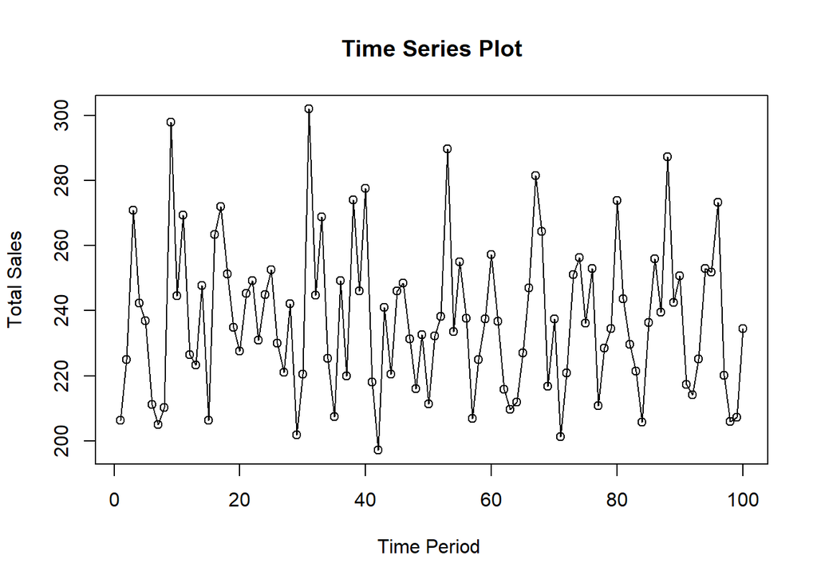

```r
ts.plot(data.ts, xlab="Time Period ", ylab="Total Sales",
        main = "Time Series Plot")
points(data.ts)
```

Data stasioner tanpa tren sehingga cocok dengan Single Moving Average (SMA) dan Single Exponential Smoothing (SES)

### Single Moving Average (SMA)

Split Data

80% Data Train; 20% Data Test

```r
# hitung jumlah data
n <- nrow(data)

# tentukan batas 80%
n_train <- floor(0.8 * n)

# bagi data
training_ma <- data[1:n_train, ]
testing_ma  <- data[(n_train+1):n, ]

# ubah ke time series
train_ma.ts <- ts(training_ma$Total_Sales)
test_ma.ts  <- ts(testing_ma$Total_Sales)
```

Plot data train

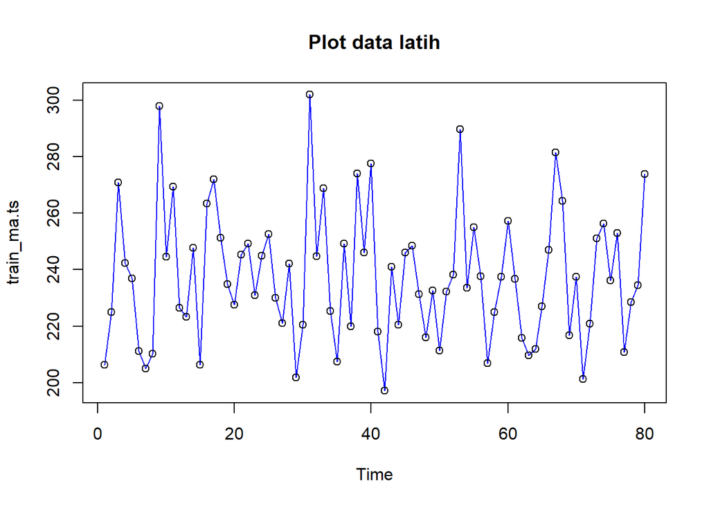

```r
plot(train_ma.ts, col="blue",main="Plot data latih")
points(train_ma.ts)
```

Plot data test

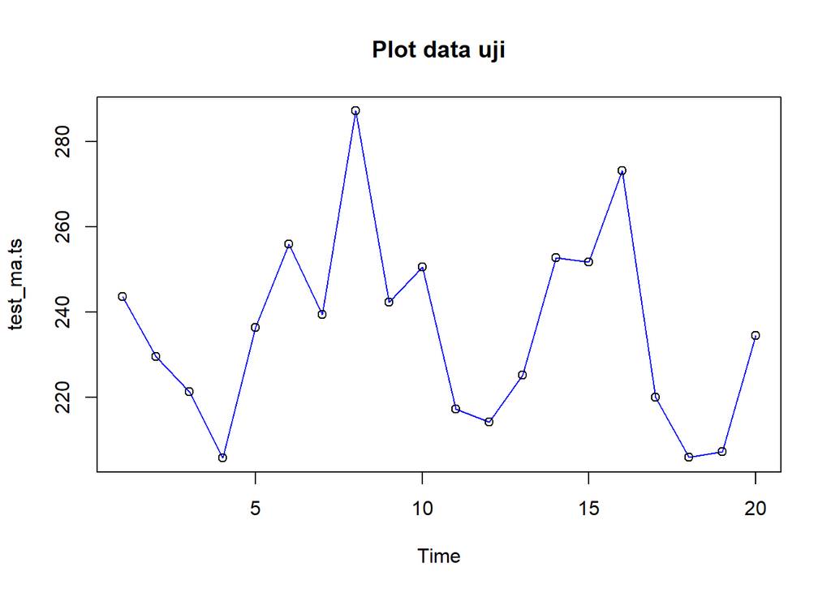

```r
plot(test_ma.ts, col="blue",main="Plot data uji")
points(test_ma.ts)
```

Plot semua data

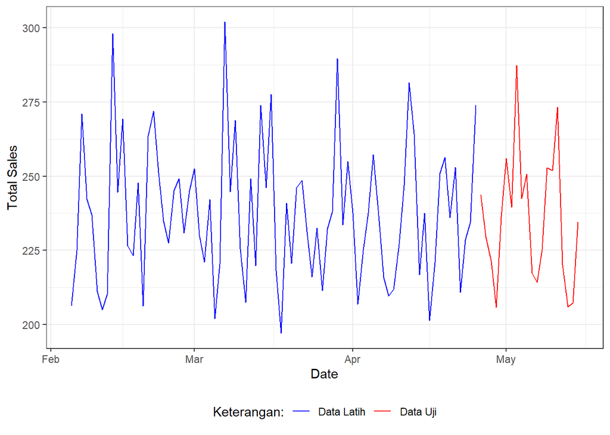

```r
ggplot() +
  geom_line(data = training_ma, aes(x = Date, y = Total_Sales, col = "Data Latih")) +
  geom_line(data = testing_ma, aes(x = Date, y = Total_Sales, col = "Data Uji")) +
  labs(x = "Date", y = "Total Sales", color = "Legend") +
   scale_colour_manual(name="Keterangan:", breaks = c("Data Latih", "Data Uji"),
                      values = c("blue", "red")) +
  theme_bw() + theme(legend.position = "bottom",
                     plot.caption = element_text(hjust=0.5, size=12))
```

```r
data.sma<-SMA(train_ma.ts, n=4)
data.sma
```

```
## Time Series:
## Start = 1
## End = 80
## Frequency = 1
##  [1]       NA       NA       NA 236.1700 243.8275 240.3675 223.8975 215.8750
##  [9] 231.1200 239.4725 255.5425 259.6025 240.9375 241.7300 225.9675 235.2050
## [17] 247.3800 248.2375 255.3850 246.4025 239.7200 239.2025 238.2125 242.5725
## [25] 244.3875 239.6200 237.1450 236.4275 223.7850 221.3925 241.6150 242.2550
## [33] 258.9775 260.2150 236.6225 237.7600 225.5200 237.6425 247.2800 254.3550
## [41] 253.9200 234.7300 233.4525 219.2200 226.2250 239.0675 236.6350 235.5050
## [49] 232.1100 222.8400 223.0875 228.6275 242.8825 248.4250 254.1225 253.9850
## [57] 233.3250 231.1775 226.7975 231.6875 239.1550 236.8525 229.8850 218.5550
## [65] 216.1150 223.8850 241.8625 254.9675 252.4050 250.0600 230.0025 219.1525
## [73] 227.7100 232.4100 241.1050 249.1000 239.0450 232.1025 231.6950 236.9425
```

```r
data.ramal<-c(NA,data.sma)
data.ramal #forecast 1 periode ke depan
```

```
##  [1]       NA       NA       NA       NA 236.1700 243.8275 240.3675 223.8975
##  [9] 215.8750 231.1200 239.4725 255.5425 259.6025 240.9375 241.7300 225.9675
## [17] 235.2050 247.3800 248.2375 255.3850 246.4025 239.7200 239.2025 238.2125
## [25] 242.5725 244.3875 239.6200 237.1450 236.4275 223.7850 221.3925 241.6150
## [33] 242.2550 258.9775 260.2150 236.6225 237.7600 225.5200 237.6425 247.2800
## [41] 254.3550 253.9200 234.7300 233.4525 219.2200 226.2250 239.0675 236.6350
## [49] 235.5050 232.1100 222.8400 223.0875 228.6275 242.8825 248.4250 254.1225
## [57] 253.9850 233.3250 231.1775 226.7975 231.6875 239.1550 236.8525 229.8850
## [65] 218.5550 216.1150 223.8850 241.8625 254.9675 252.4050 250.0600 230.0025
## [73] 219.1525 227.7100 232.4100 241.1050 249.1000 239.0450 232.1025 231.6950
## [81] 236.9425
```

```r
data.gab<-cbind(
  aktual=c(data.ts),
  pemulusan=c(data.sma,rep(NA,24)),
  ramalan=c(data.ramal,rep(data.ramal[length(data.ramal)],23)))
data.gab #forecast 24 periode ke depan
```

```
##        aktual pemulusan  ramalan
##   [1,] 206.33        NA       NA
##   [2,] 225.04        NA       NA
##   [3,] 270.94        NA       NA
##   [4,] 242.37  236.1700       NA
##   [5,] 236.96  243.8275 236.1700
##   [6,] 211.20  240.3675 243.8275
##   [7,] 205.06  223.8975 240.3675
##   [8,] 210.28  215.8750 223.8975
##   [9,] 297.94  231.1200 215.8750
##  [10,] 244.61  239.4725 231.1200
##  [11,] 269.34  255.5425 239.4725
##  [12,] 226.52  259.6025 255.5425
##  [13,] 223.28  240.9375 259.6025
##  [14,] 247.78  241.7300 240.9375
```

[output cut: 90 more lines]

Plot hasil peramalan

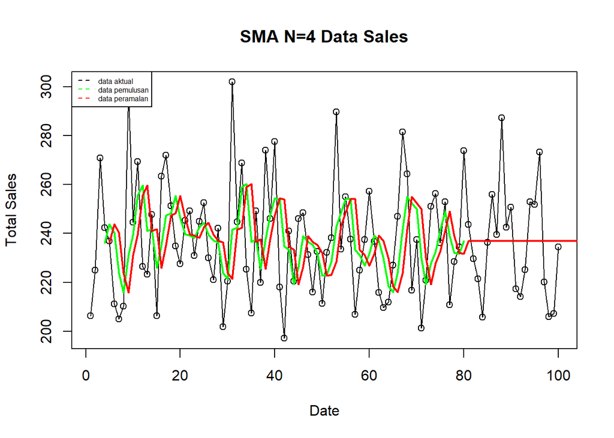

```r
ts.plot(data.ts, xlab="Date", ylab="Total Sales", main= "SMA N=4 Data Sales")
points(data.ts)
lines(data.gab[,2],col="green",lwd=2)
lines(data.gab[,3],col="red",lwd=2)
legend("topleft",c("data aktual","data pemulusan","data peramalan"), lty=8, col=c("black","green","red"), cex=0.5)
```

```r
#Menghitung nilai keakuratan data latih
error_train.sma = train_ma.ts-data.ramal[1:length(train_ma.ts)]

SSE_train.sma = sum(error_train.sma[5:length(train_ma.ts)]^2)
MSE_train.sma = mean(error_train.sma[5:length(train_ma.ts)]^2)
MAPE_train.sma = mean(abs((error_train.sma[5:length(train_ma.ts)]/train_ma.ts[5:length(train_ma.ts)])*100))

akurasi_train.sma <- matrix(c(SSE_train.sma, MSE_train.sma, MAPE_train.sma))
row.names(akurasi_train.sma)<- c("SSE", "MSE", "MAPE")
colnames(akurasi_train.sma) <- c("Akurasi m = 4")
akurasi_train.sma
```

```
##      Akurasi m = 4
## SSE   65014.817662
## MSE     855.458127
## MAPE      9.703136
```

MAPE data train pada metode pemulusan SMA sekitar 9%. Termasuk nilai akurasi sangat akurat.

```r
# Ambil data aktual (baris 81-104, kolom 1)
actual_test <- data.gab[81:104, 1]

# Ambil data ramalan (baris 81-104, kolom 3)
forecast_test <- data.gab[81:104, 3]

# Hitung error
error_test.sma <- actual_test - forecast_test

# Hitung metrik
SSE_test.sma <- sum(error_test.sma^2)
MSE_test.sma <- mean(error_test.sma^2)
MAPE_test.sma <- mean(abs(error_test.sma / actual_test * 100))

# Simpan dalam matrix
akurasi_test.sma <- matrix(c(SSE_test.sma, MSE_test.sma, MAPE_test.sma))
row.names(akurasi_test.sma) <- c("SSE", "MSE", "MAPE")
colnames(akurasi_test.sma) <- c("Akurasi m = 4")

akurasi_test.sma
```

```
##      Akurasi m = 4
## SSE   11642.806200
## MSE     485.116925
## MAPE      7.718333
```

MAPE < 10%, maka nilai akurasi sangat baik.

### Single Exponential Smoothing

Split Data

80% Data train; 20% Data test

```r
# jumlah baris data
n <- nrow(data)

# hitung batas 80%
n_train <- floor(0.8 * n)

# bagi data
training <- data[1:n_train, ]
testing  <- data[(n_train+1):n, ]

# ubah ke time series
train.ts <- ts(training$Total_Sales)
test.ts  <- ts(testing$Total_Sales)
```

Plot data train

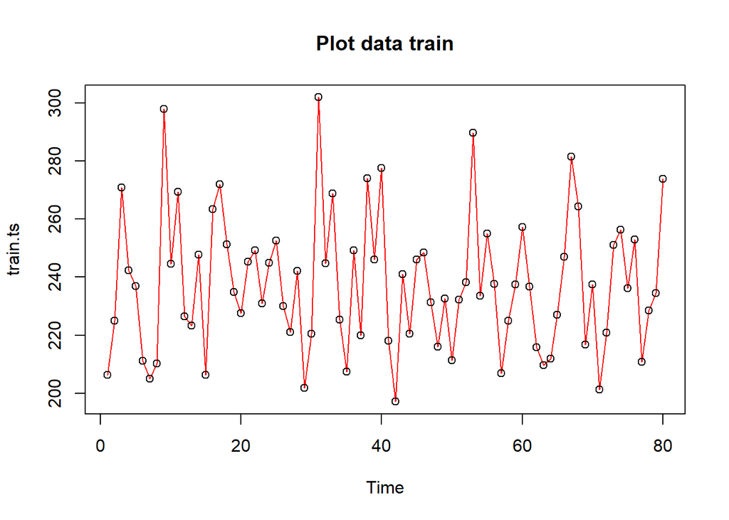

```r
plot(train.ts, col="red",main="Plot data train")
points(train.ts)
```

Plot data test

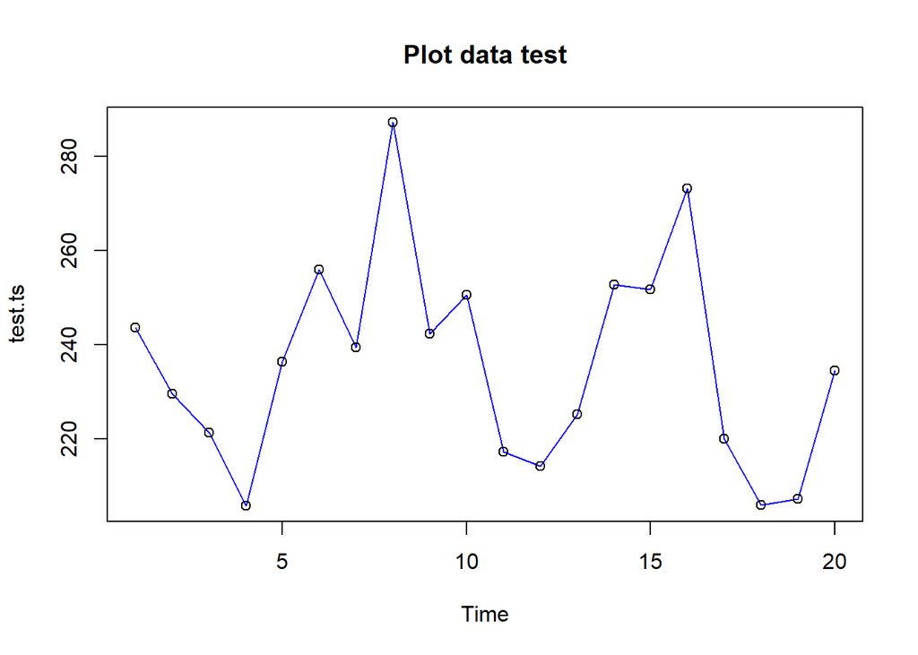

```r
plot(test.ts, col="blue",main="Plot data test")
points(test.ts)
```

Plot gabungan

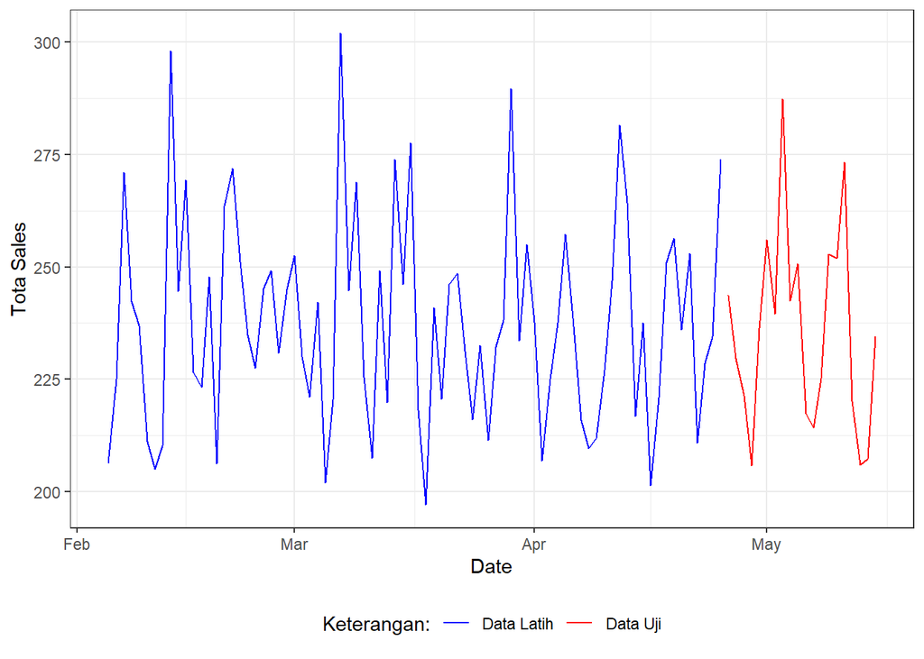

```r
library(ggplot2)
ggplot() +
  geom_line(data = training, aes(x = Date, y = Total_Sales, col = "Data Latih")) +
  geom_line(data = testing, aes(x = Date, y = Total_Sales, col = "Data Uji")) +
  labs(x = "Date", y = "Tota Sales", color = "Legend") +
  scale_colour_manual(name="Keterangan:", breaks = c("Data Latih", "Data Uji"),
                      values = c("blue", "red")) +
  theme_bw() + theme(legend.position = "bottom",
                     plot.caption = element_text(hjust=0.5, size=12))
```

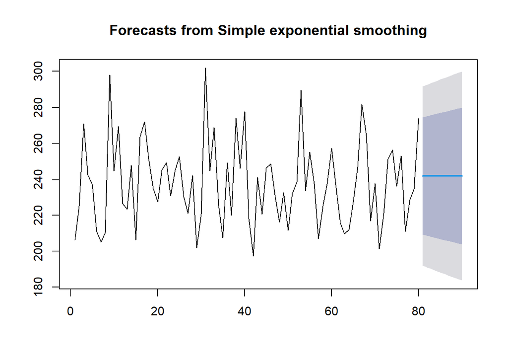

```r
#Cara 1 (fungsi ses)
ses.1 <- ses(train.ts, h = 10, alpha = 0.2)
plot(ses.1)
```

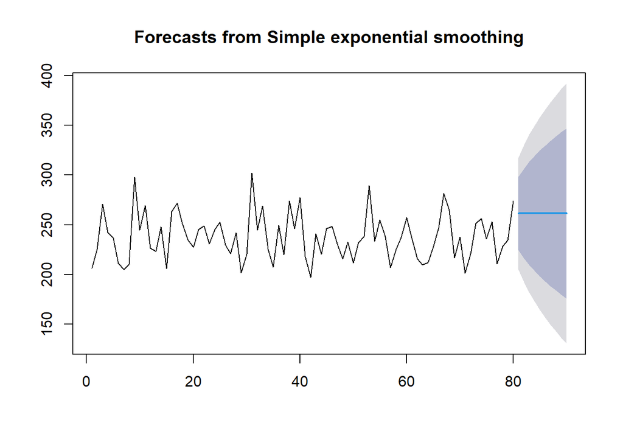

```r
ses.2<- ses(train.ts, h = 10, alpha = 0.7)
plot(ses.2)
```

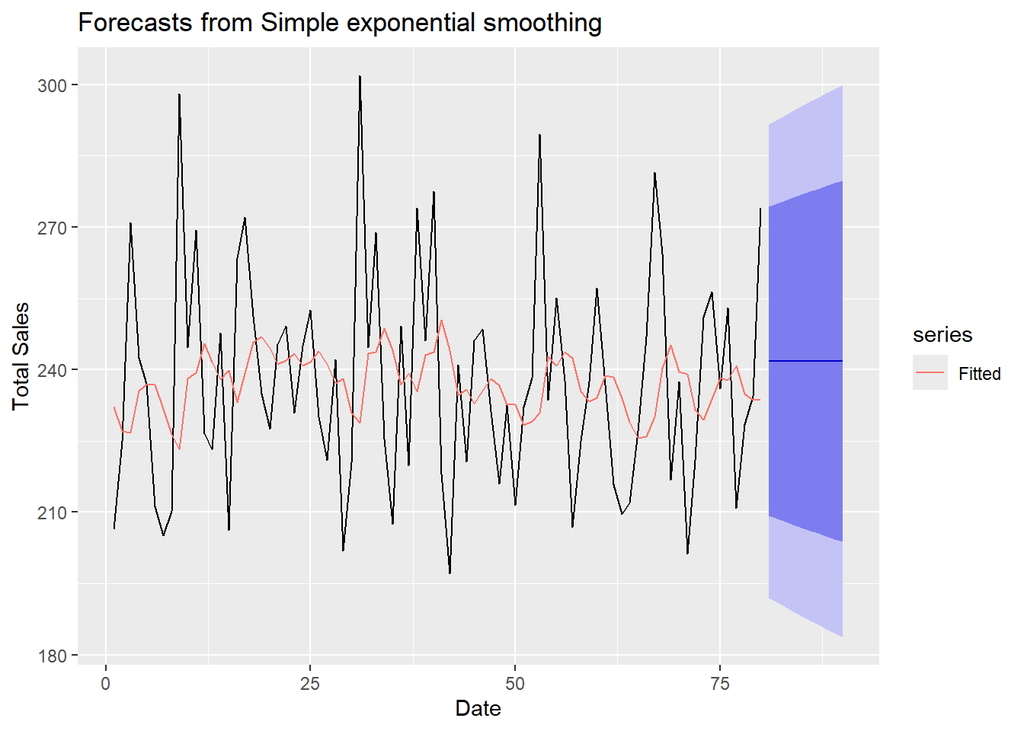

```r
autoplot(ses.1) +
  autolayer(fitted(ses.1), series="Fitted") +
  ylab("Total Sales") + xlab("Date")
```

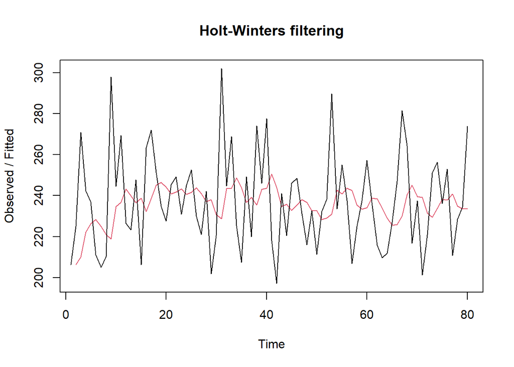

```r
#Cara 2 (fungsi Holtwinter)
ses1<- HoltWinters(train.ts, gamma = FALSE, beta = FALSE, alpha = 0.2)
plot(ses1)
```

```r
#ramalan
ramalan1<- forecast(ses1, h=10)
ramalan1
```

```
##    Point Forecast    Lo 80    Hi 80    Lo 95    Hi 95
## 81       241.7957 208.7643 274.8271 191.2785 292.3128
## 82       241.7957 208.1101 275.4812 190.2781 293.3132
## 83       241.7957 207.4684 276.1229 189.2967 294.2946
## 84       241.7957 206.8385 276.7528 188.3333 295.2580
## 85       241.7957 206.2198 277.3716 187.3870 296.2043
## 86       241.7957 205.6116 277.9797 186.4569 297.1344
## 87       241.7957 205.0135 278.5779 185.5421 298.0492
## 88       241.7957 204.4249 279.1664 184.6420 298.9493
## 89       241.7957 203.8455 279.7458 183.7559 299.8354
## 90       241.7957 203.2748 280.3165 182.8830 300.7083
```

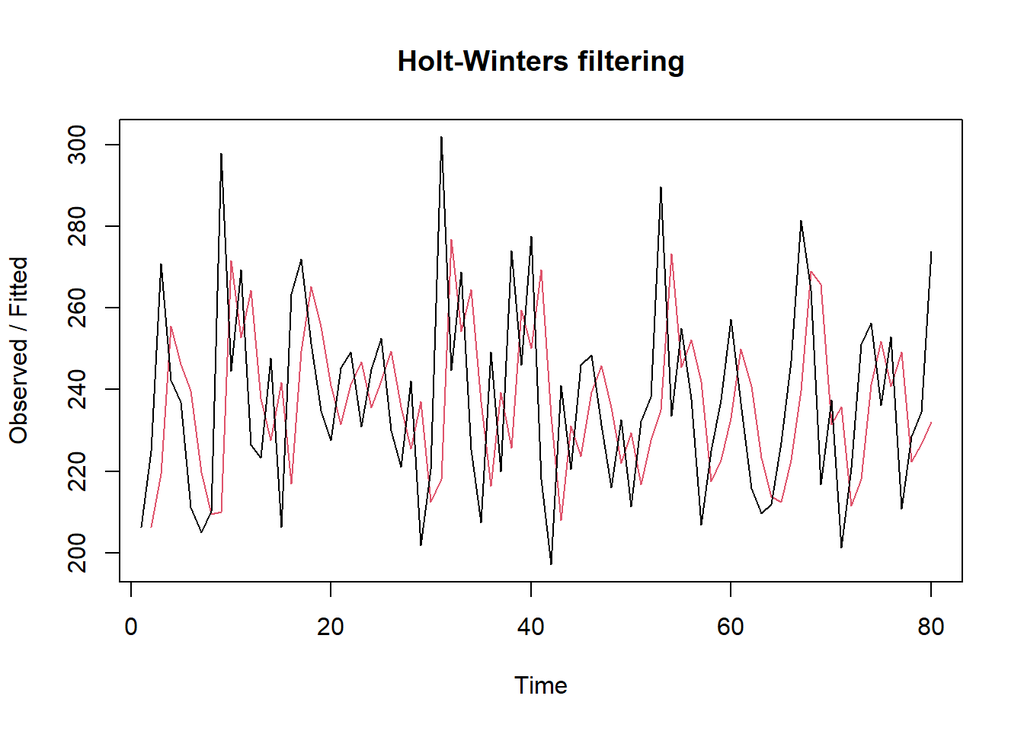

```r
ses2<- HoltWinters(train.ts, gamma = FALSE, beta = FALSE, alpha = 0.7)
plot(ses2)
```

```r
#ramalan
ramalan2<- forecast(ses2, h=10)
ramalan2
```

```
##    Point Forecast    Lo 80    Hi 80    Lo 95    Hi 95
## 81       261.3793 224.5882 298.1705 205.1121 317.6465
## 82       261.3793 216.4700 306.2886 192.6965 330.0622
## 83       261.3793 209.6096 313.1490 182.2044 340.5543
## 84       261.3793 203.5575 319.2011 172.9485 349.8102
## 85       261.3793 198.0815 324.6772 164.5736 358.1851
## 86       261.3793 193.0428 329.7158 156.8677 365.8910
## 87       261.3793 188.3510 334.4076 149.6921 373.0665
## 88       261.3793 183.9429 338.8157 142.9506 379.8081
## 89       261.3793 179.7726 342.9860 136.5727 386.1860
## 90       261.3793 175.8053 346.9533 130.5052 392.2535
```

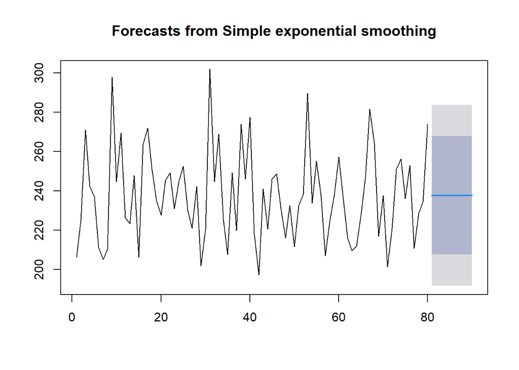

```r
#SES
ses.opt <- ses(train.ts, h = 10, alpha = NULL)
plot(ses.opt)
```

```r
ses.opt
```

```
##    Point Forecast    Lo 80    Hi 80    Lo 95    Hi 95
## 81       237.7192 207.6147 267.8238 191.6783 283.7602
## 82       237.7192 207.6147 267.8238 191.6783 283.7602
## 83       237.7192 207.6147 267.8238 191.6783 283.7602
## 84       237.7192 207.6147 267.8238 191.6783 283.7602
## 85       237.7192 207.6147 267.8238 191.6783 283.7602
## 86       237.7192 207.6147 267.8238 191.6783 283.7602
## 87       237.7192 207.6147 267.8238 191.6783 283.7602
## 88       237.7192 207.6147 267.8238 191.6783 283.7602
## 89       237.7192 207.6147 267.8238 191.6783 283.7602
## 90       237.7192 207.6147 267.8238 191.6783 283.7602
```

```r
#Lamda Optimum Holt Winter
HWopt<- HoltWinters(train.ts, gamma = FALSE, beta = FALSE,alpha = NULL)
HWopt
```

```
## Holt-Winters exponential smoothing without trend and without seasonal component.
##
## Call:
## HoltWinters(x = train.ts, alpha = NULL, beta = FALSE, gamma = FALSE)
##
## Smoothing parameters:
##  alpha: 0.1255898
##  beta : FALSE
##  gamma: FALSE
##
## Coefficients:
##       [,1]
## a 239.4429
```

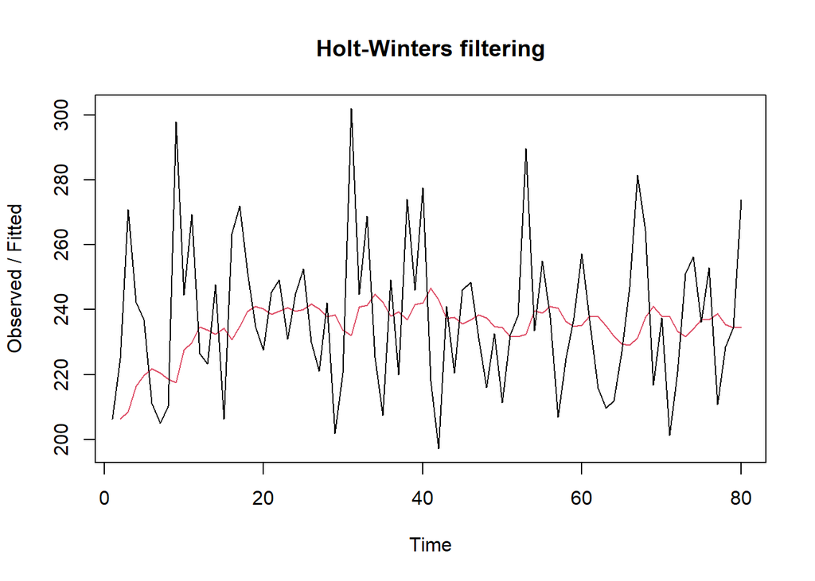

```r
plot(HWopt)
```

```r
#ramalan
ramalanopt<- forecast(HWopt, h=10)
ramalanopt
```

```
##    Point Forecast    Lo 80    Hi 80    Lo 95    Hi 95
## 81       239.4429 206.8734 272.0124 189.6321 289.2537
## 82       239.4429 206.6175 272.2683 189.2408 289.6449
## 83       239.4429 206.3637 272.5221 188.8526 290.0332
## 84       239.4429 206.1117 272.7741 188.4673 290.4185
## 85       239.4429 205.8617 273.0241 188.0849 290.8009
## 86       239.4429 205.6135 273.2723 187.7053 291.1805
## 87       239.4429 205.3671 273.5187 187.3284 291.5574
## 88       239.4429 205.1225 273.7633 186.9543 291.9315
## 89       239.4429 204.8796 274.0062 186.5829 292.3029
## 90       239.4429 204.6384 274.2474 186.2140 292.6718
```

Akurasi data train

```r
#Keakuratan Metode
#Pada data training

# SES dengan alpha = 0.2
SSE1<-ses1$SSE
MSE1<-ses1$SSE/length(train.ts)
RMSE1<-sqrt(MSE1)

akurasi1 <- matrix(c(SSE1,MSE1,RMSE1))
row.names(akurasi1)<- c("SSE", "MSE", "RMSE")
colnames(akurasi1) <- c("Akurasi lamda=0.2")
akurasi1
```

```
##      Akurasi lamda=0.2
## SSE        52215.49827
## MSE          652.69373
## RMSE          25.54787
```

```r
# SES dengan alpha = 0.7
SSE2<-ses2$SSE
MSE2<-ses2$SSE/length(train.ts)
RMSE2<-sqrt(MSE2)

akurasi2 <- matrix(c(SSE2,MSE2,RMSE2))
row.names(akurasi2)<- c("SSE", "MSE", "RMSE")
colnames(akurasi2) <- c("Akurasi lamda=0.7")
akurasi2
```

```
##      Akurasi lamda=0.7
## SSE        64363.16742
## MSE          804.53959
## RMSE          28.36441
```

Akurasi data test

```r
# jumlah observasi uji
n_test <- nrow(testing)

# error (ramalan - aktual), samakan panjang dan tipe numeric
e1   <- as.numeric(ramalan1$mean)[1:n_test] - as.numeric(testing$Total_Sales)
e2   <- as.numeric(ramalan2$mean)[1:n_test] - as.numeric(testing$Total_Sales)
eopt <- as.numeric(ramalanopt$mean)[1:n_test] - as.numeric(testing$Total_Sales)

# SSE / MSE / RMSE untuk masing-masing model (abaikan NA)
SSEtesting1  <- sum(e1^2,  na.rm = TRUE)
MSEtesting1  <- mean(e1^2, na.rm = TRUE)
RMSEtesting1 <- sqrt(MSEtesting1)

SSEtesting2  <- sum(e2^2,  na.rm = TRUE)
MSEtesting2  <- mean(e2^2, na.rm = TRUE)
RMSEtesting2 <- sqrt(MSEtesting2)

SSEtestingopt  <- sum(eopt^2,  na.rm = TRUE)
MSEtestingopt  <- mean(eopt^2, na.rm = TRUE)
RMSEtestingopt <- sqrt(MSEtestingopt)

# Tabel ringkas
akurasitesting_SSE <- matrix(c(SSEtesting1, SSEtesting2, SSEtestingopt),
                             nrow = 3,
                             dimnames = list(c("SSE1","SSE2","SSEopt"), "Nilai"))
akurasitesting_MSE <- matrix(c(MSEtesting1, MSEtesting2, MSEtestingopt),
                             nrow = 3,
                             dimnames = list(c("MSE1","MSE2","MSEopt"), "Nilai"))
akurasitesting_RMSE <- matrix(c(RMSEtesting1, RMSEtesting2, RMSEtestingopt),
                              nrow = 3,
                              dimnames = list(c("RMSE1","RMSE2","RMSEopt"), "Nilai"))

akurasitesting_SSE
```

```
##           Nilai
## SSE1   4240.423
## SSE2   8273.676
## SSEopt 4271.984
```

Dari sini: SSE1 < SSE2, artinya model 1 lebih baik daripada model 2.

SSEopt (model optimal hasil tuning) hampir sama dengan SSE1 → model 1 sudah cukup bagus.

```r
akurasitesting_MSE
```

```
##           Nilai
## MSE1   424.0423
## MSE2   827.3676
## MSEopt 427.1984
```

Hasilnya sama: MSE1 paling kecil, model 1 lebih baik dari model 2.

MSEopt hampir identik dengan MSE1.

```r
akurasitesting_RMSE
```

```
##            Nilai
## RMSE1   20.59229
## RMSE2   28.76400
## RMSEopt 20.66878
```

Artinya pada model 1 dan model optimal, rata-rata error per prediksi sekitar 20 unit.

Model 2 jauh lebih buruk (error rata-rata hampir 29 unit).

Kesimpulan

Model 1 memberikan hasil terbaik (error paling kecil).

Model 2 jelas lebih buruk (SSE, MSE, RMSE lebih besar).

Model optimal (SSEopt/MSEopt/RMSEopt) hampir sama dengan Model 1, artinya tuning parameter tidak banyak memperbaiki performa → Model 1 sudah cukup baik.

Dari sudut pandang praktis, model terbaik menghasilkan error rata-rata sekitar 20 unit penjualan (Total Sales) per periode.